# Clustering and classification

This week we learned about clustering and classification methods.

```r
# load the necessary packages and set scientific notation off

options(scipen = 999)

library("MASS")
library("ggplot2")
library("dplyr")
library("GGally")
```

## Overview of the data

In this week analyses we use the `Boston` dataset from `Mass` package. The data describes housing values in suburbs of Boston from the 1970s. More information can be found here: https://stat.ethz.ch/R-manual/R-devel/library/MASS/html/Boston.html

```r
# load the data

data("Boston")

# explore the structure and dimensions
str(Boston)
```

```
## 'data.frame':    506 obs. of  14 variables:
##  $ crim   : num  0.00632 0.02731 0.02729 0.03237 0.06905 ...
##  $ zn     : num  18 0 0 0 0 0 12.5 12.5 12.5 12.5 ...
##  $ indus  : num  2.31 7.07 7.07 2.18 2.18 2.18 7.87 7.87 7.87 7.87 ...
##  $ chas   : int  0 0 0 0 0 0 0 0 0 0 ...
##  $ nox    : num  0.538 0.469 0.469 0.458 0.458 0.458 0.524 0.524 0.524 0.524 ...
##  $ rm     : num  6.58 6.42 7.18 7 7.15 ...
##  $ age    : num  65.2 78.9 61.1 45.8 54.2 58.7 66.6 96.1 100 85.9 ...
##  $ dis    : num  4.09 4.97 4.97 6.06 6.06 ...
##  $ rad    : int  1 2 2 3 3 3 5 5 5 5 ...
##  $ tax    : num  296 242 242 222 222 222 311 311 311 311 ...
##  $ ptratio: num  15.3 17.8 17.8 18.7 18.7 18.7 15.2 15.2 15.2 15.2 ...
##  $ black  : num  397 397 393 395 397 ...
##  $ lstat  : num  4.98 9.14 4.03 2.94 5.33 ...
##  $ medv   : num  24 21.6 34.7 33.4 36.2 28.7 22.9 27.1 16.5 18.9 ...
```

```r
dim(Boston)
```

```
## [1] 506  14
```

The Boston data consists 506 observations and 14 variables, which include town’s per capita crime rate, a number of variables reflecting the average socioeconomic status of the area and the demographics or the residents, general information about the location (e.g. proximity highways and the Charles River) and air quality.

Let’s have a closer look at the data and the variables.

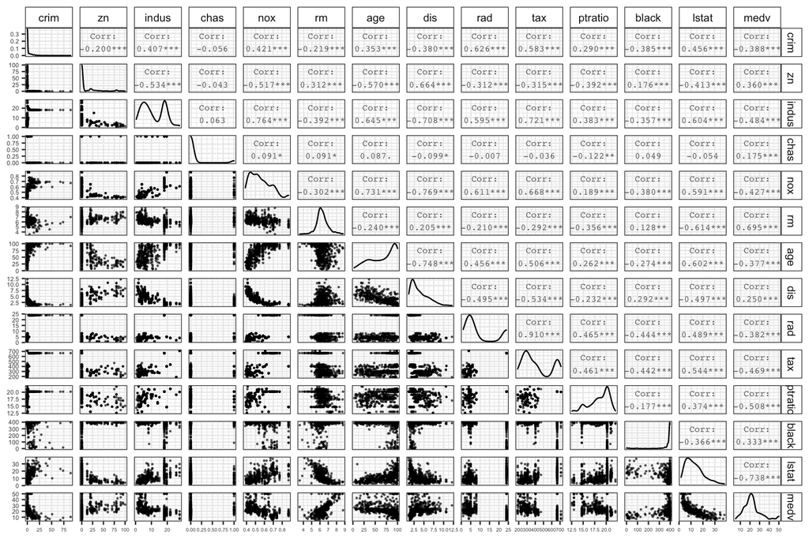

```r
plot1 <- ggpairs(Boston,
             mapping = aes(alpha = 0.1),
             lower = list(continuous = wrap("points", size = 0.3)),
             upper = list(continuous = wrap("cor", size = 2.5)),
             ) +
  theme_bw() +
  theme(strip.background = element_rect(fill = "white"),
        axis.text.x = element_text(size=4),
        axis.text.y = element_text(size=5))

plot1
```

```r
summary(Boston)
```

```
##       crim                zn             indus            chas
##  Min.   : 0.00632   Min.   :  0.00   Min.   : 0.46   Min.   :0.00000
##  1st Qu.: 0.08205   1st Qu.:  0.00   1st Qu.: 5.19   1st Qu.:0.00000
##  Median : 0.25651   Median :  0.00   Median : 9.69   Median :0.00000
##  Mean   : 3.61352   Mean   : 11.36   Mean   :11.14   Mean   :0.06917
##  3rd Qu.: 3.67708   3rd Qu.: 12.50   3rd Qu.:18.10   3rd Qu.:0.00000
##  Max.   :88.97620   Max.   :100.00   Max.   :27.74   Max.   :1.00000
##       nox               rm             age              dis
##  Min.   :0.3850   Min.   :3.561   Min.   :  2.90   Min.   : 1.130
##  1st Qu.:0.4490   1st Qu.:5.886   1st Qu.: 45.02   1st Qu.: 2.100
##  Median :0.5380   Median :6.208   Median : 77.50   Median : 3.207
##  Mean   :0.5547   Mean   :6.285   Mean   : 68.57   Mean   : 3.795
##  3rd Qu.:0.6240   3rd Qu.:6.623   3rd Qu.: 94.08   3rd Qu.: 5.188
##  Max.   :0.8710   Max.   :8.780   Max.   :100.00   Max.   :12.127
##       rad              tax           ptratio          black
##  Min.   : 1.000   Min.   :187.0   Min.   :12.60   Min.   :  0.32
##  1st Qu.: 4.000   1st Qu.:279.0   1st Qu.:17.40   1st Qu.:375.38
##  Median : 5.000   Median :330.0   Median :19.05   Median :391.44
##  Mean   : 9.549   Mean   :408.2   Mean   :18.46   Mean   :356.67
##  3rd Qu.:24.000   3rd Qu.:666.0   3rd Qu.:20.20   3rd Qu.:396.23
##  Max.   :24.000   Max.   :711.0   Max.   :22.00   Max.   :396.90
##      lstat            medv
##  Min.   : 1.73   Min.   : 5.00
##  1st Qu.: 6.95   1st Qu.:17.02
##  Median :11.36   Median :21.20
##  Mean   :12.65   Mean   :22.53
##  3rd Qu.:16.95   3rd Qu.:25.00
##  Max.   :37.97   Max.   :50.00
```

Some of the variables are very heavily skewed towards lower values, most notably `crim` (the per capita rate by town), `zn` (proportion of residential land zoned for large lots) and `chas` (a dummy variable describing whether or not the area is next to the Charles River). Therefore the data consists of areas that mostly have low crime rates, smaller residential lots, and are not next to the river. The variables `dis` (distance to employment centers) and `lstat` (percent of the lower status of the population) are also skewed towards the lower values, so most areas are close to the employment centers and have a low percent of low status residents. On the other hand, variables `age`, `ptratio`, and `black` are skewed towards higher values, meaning the data includes more areas with older houses, high pupil-teacher ratio, and fewer black people. A couple of variables have very clear two peaks: `indus` (proportion of non-retail business acres), `rad` (accessibility to radial highways), and `tax` (property tax-rate). The variable `nox`, describing the nitrogen oxides concentration also has mostly quite low values, while `medv`, median value of owner-occupied homes, has its peak around the middle values.

There are a number of substantial correlations between the variables, and we can instantly see some interesting patterns in the data from the scatterplots, e.g. the nitrogen oxides concentration seems to be higher when the houses in the area are older, and lower when the distance to the employment centres is higher, and higher percent of the population that is of lower status seems to be associated with a decrease in the median value of owner-occupied homes. Nothing too surprising.

## Standardizing the data & creating train and test datasets

Next we can standardize the data using the function `scale`.

```r
boston_scaled <- scale(Boston)

summary(boston_scaled)
```

```
##       crim                 zn               indus              chas
##  Min.   :-0.419367   Min.   :-0.48724   Min.   :-1.5563   Min.   :-0.2723
##  1st Qu.:-0.410563   1st Qu.:-0.48724   1st Qu.:-0.8668   1st Qu.:-0.2723
##  Median :-0.390280   Median :-0.48724   Median :-0.2109   Median :-0.2723
##  Mean   : 0.000000   Mean   : 0.00000   Mean   : 0.0000   Mean   : 0.0000
##  3rd Qu.: 0.007389   3rd Qu.: 0.04872   3rd Qu.: 1.0150   3rd Qu.:-0.2723
##  Max.   : 9.924110   Max.   : 3.80047   Max.   : 2.4202   Max.   : 3.6648
##       nox                rm               age               dis
##  Min.   :-1.4644   Min.   :-3.8764   Min.   :-2.3331   Min.   :-1.2658
##  1st Qu.:-0.9121   1st Qu.:-0.5681   1st Qu.:-0.8366   1st Qu.:-0.8049
##  Median :-0.1441   Median :-0.1084   Median : 0.3171   Median :-0.2790
##  Mean   : 0.0000   Mean   : 0.0000   Mean   : 0.0000   Mean   : 0.0000
##  3rd Qu.: 0.5981   3rd Qu.: 0.4823   3rd Qu.: 0.9059   3rd Qu.: 0.6617
##  Max.   : 2.7296   Max.   : 3.5515   Max.   : 1.1164   Max.   : 3.9566
##       rad               tax             ptratio            black
##  Min.   :-0.9819   Min.   :-1.3127   Min.   :-2.7047   Min.   :-3.9033
##  1st Qu.:-0.6373   1st Qu.:-0.7668   1st Qu.:-0.4876   1st Qu.: 0.2049
##  Median :-0.5225   Median :-0.4642   Median : 0.2746   Median : 0.3808
##  Mean   : 0.0000   Mean   : 0.0000   Mean   : 0.0000   Mean   : 0.0000
##  3rd Qu.: 1.6596   3rd Qu.: 1.5294   3rd Qu.: 0.8058   3rd Qu.: 0.4332
##  Max.   : 1.6596   Max.   : 1.7964   Max.   : 1.6372   Max.   : 0.4406
##      lstat              medv
##  Min.   :-1.5296   Min.   :-1.9063
##  1st Qu.:-0.7986   1st Qu.:-0.5989
##  Median :-0.1811   Median :-0.1449
##  Mean   : 0.0000   Mean   : 0.0000
##  3rd Qu.: 0.6024   3rd Qu.: 0.2683
##  Max.   : 3.5453   Max.   : 2.9865
```

This takes each value, calculates the difference between it and the variable mean, and divides it by the standard deviation of the variable. The scaled values represents by how many standard deviations does the observation differ from the variable mean. The means of each scaled variables is now 0 and the values that were originally below the mean are negative, and values above the mean are positive. For example, the maximum value of crime rates in the original data is 88.9762, which is 85.3626764 above the mean: the standard deviation of crime rates is 8.6015451, so the maximum value is 85.3626764 / 8.6015451 = 9.9241096 above the mean. This is the new maximum value in the scaled data.

Let’s then replace the crime rate variable with a categorical variable of the crime rate using quantiles as the break points.

```r
# change the class to dataframe
boston_scaled <- as.data.frame(boston_scaled)

# define the breaks
bins <- quantile(boston_scaled$crim)

# create the categorical variable
boston_scaled$crime <- cut(boston_scaled$crim, breaks = bins, include.lowest = TRUE, labels = c("low", "med_low", "med_high", "high"))

# remove the original crime rate variable
boston_scaled <- dplyr::select(boston_scaled, -crim)
```

## Linear discriminant analysis

First, we will divide the dataset to train and test sets: we will first use the train set to do train our classification model and then see how well our model can predict the classes in the test dataset.

```r
# choose randomly 80% of the rows in the data for the train set
ind <- sample(nrow(boston_scaled),  size = nrow(boston_scaled) * 0.8)

# create train set
train <- boston_scaled[ind,]

# create test set
test <- boston_scaled[-ind,]
```

Next, we will fit the linear discriminant analysis on the train set using the categorical crime rate variable `crime` as the target variable, and all the other variables as predictors.

```r
# Fit the model
lda.crime <- lda(crime ~., data = train)

lda.crime
```

```
## Call:
## lda(crime ~ ., data = train)
##
## Prior probabilities of groups:
##       low   med_low  med_high      high
## 0.2574257 0.2450495 0.2425743 0.2549505
##
## Group means:
##                  zn      indus         chas        nox         rm        age
## low       0.9223457 -0.9112350 -0.083045403 -0.8565304  0.4745722 -0.8455355
## med_low  -0.1180204 -0.2863932  0.006051757 -0.5638923 -0.1303037 -0.2985266
## med_high -0.3988608  0.1703603  0.089241362  0.3311800  0.1350320  0.4039964
## high     -0.4872402  1.0170891 -0.042983423  1.0748201 -0.4365418  0.8235292
##                 dis        rad        tax     ptratio      black       lstat
## low       0.8481401 -0.6914416 -0.7671024 -0.43248332  0.3770128 -0.78060009
## med_low   0.3253183 -0.5596066 -0.4869280 -0.03918183  0.3166674 -0.09609139
## med_high -0.3513478 -0.4275601 -0.3328305 -0.22266806  0.1000274 -0.03385165
## high     -0.8497680  1.6384176  1.5142626  0.78111358 -0.7903022  0.86288127
##                  medv
## low       0.545205209
## med_low  -0.008509295
## med_high  0.188929235
## high     -0.670725110
##
## Coefficients of linear discriminants:
##                  LD1          LD2         LD3
## zn       0.080003017  0.720260873 -0.88257373
## indus    0.003798145 -0.290664083  0.22311210
## chas    -0.107955680 -0.003001129  0.14061801
## nox      0.385973482 -0.704652098 -1.42665698
## rm      -0.112322305 -0.082201199 -0.18694421
## age      0.314794630 -0.345775376 -0.21623147
## dis     -0.019101969 -0.268270684  0.09136953
## rad      3.401759107  0.882664588 -0.08571472
## tax      0.046747826  0.050161593  0.63891087
## ptratio  0.093891143  0.056403231 -0.25372026
## black   -0.103500083  0.042462658  0.16816252
## lstat    0.204273899 -0.192973469  0.52945076
## medv     0.183908574 -0.365665042 -0.14060722
##
## Proportion of trace:
##    LD1    LD2    LD3
## 0.9570 0.0307 0.0123
```

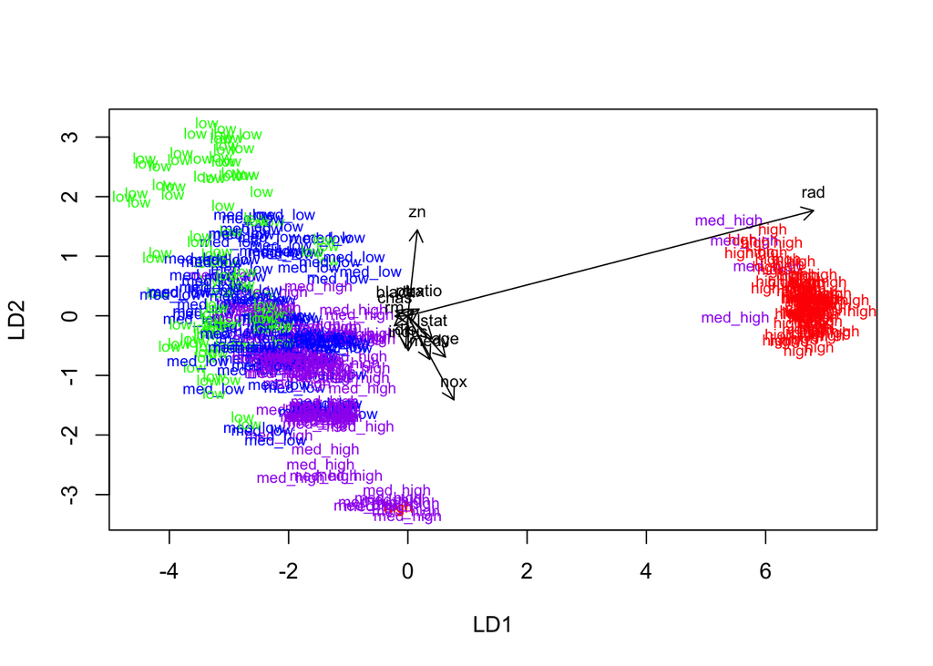

```r
# Draw the LDA biplot

# target classes as numeric
classes <- as.numeric(train$crime)

# the function for lda biplot arrows
lda.arrows <- function(x, myscale = 1, arrow_heads = 0.1, color = "black", tex = 0.75, choices = c(1,2)){
  heads <- coef(x)
  arrows(x0 = 0, y0 = 0,
         x1 = myscale * heads[,choices[1]],
         y1 = myscale * heads[,choices[2]], col=color, length = arrow_heads)
  text(myscale * heads[,choices], labels = row.names(heads),
       cex = tex, col=color, pos=3)
}

# define the colors for the plot from green (low) to red (high)
cols <- c("green", "blue", "purple", "red")
cols1 <- cols[classes]

# plot the lda results
plot(lda.crime, dimen= 2, col = cols1, pch = classes)
lda.arrows(lda.crime, myscale = 2)
```

We can see from the plot that high crime rates cluster together very clearly separate from the other categories. The other categories also form clusters, although there is much more overlap between the categories. The arrows show that the variable `rad` (the accessibility of radial highways) contributes most to the separation of the groups: those in the high crime rate group also have clearly higher values on this variable compared to other groups. Variables `zn` and `nox` seem to contribute more to the separation between the low, medium low, and medium high groups, with higher nitrogen oxides levels being related to higher crime rates, and proportion of large residential plots being related to lower crime rates. The same can be seen from the table of group means.

## Predictions

```r
# save crime rate categories from test data
correct_classes <- test$crime

# remove original crime rate categories
test <- dplyr::select(test, -crime)

# predict classes with the model on the test data
lda.pred <- predict(lda.crime, newdata = test)

# crosstabulate results
table(correct = correct_classes, predicted = lda.pred$class)
```

```
##           predicted
## correct    low med_low med_high high
##   low       16       5        2    0
##   med_low    5      18        4    0
##   med_high   0       9       17    2
##   high       0       0        0   24
```

It looks like that the predictions are pretty good: in all categories, the correct predictions are in the majority. The “high” group was predicted most accurately, which can also be seen from the previous plot, as the high values formed most clearly a separate cluster.

## K-means clustering

Let’s reload the Boston data, standardize it again, inspect the distances, and run the k-means algorithm on this data.

```r
# reload the Boston data
data("Boston")

# standardize the dataset
boston_scaled <- scale(Boston)

# calculate distances between observations
dist_eu <- dist(boston_scaled)
summary(dist_eu)
```

```
##    Min. 1st Qu.  Median    Mean 3rd Qu.    Max.
##  0.1343  3.4625  4.8241  4.9111  6.1863 14.3970
```

```r
# run the k-means algorithm
km <- kmeans(boston_scaled, centers = 4)
km
```

```
## K-means clustering with 4 clusters of sizes 85, 53, 207, 161
##
## Cluster means:
##         crim         zn      indus        chas        nox         rm        age
## 1 -0.4123980  1.8513293 -1.0969530 -0.22601024 -1.1375261  0.6170389 -1.3881521
## 2 -0.3341857 -0.1369421 -0.5709571  0.91622949 -0.1349892  1.6538269  0.2338847
## 3 -0.3804858 -0.3461806 -0.2727872 -0.10115080 -0.3870847 -0.2886676 -0.1101296
## 4  0.8169331 -0.4872402  1.1178179 -0.05224272  1.1426751 -0.4990493  0.7974774
##          dis        rad        tax    ptratio      black       lstat       medv
## 1  1.5133543 -0.6197663 -0.6078716 -0.6913384  0.3548885 -0.90787355  0.6820708
## 2 -0.3551230 -0.3794677 -0.6255348 -0.9607918  0.3197676 -0.97018595  1.6944654
## 3  0.1320396 -0.5929459 -0.5934010  0.0761018  0.2840658 -0.08205528 -0.1459139
## 4 -0.8518372  1.2144828  1.2897916  0.5834327 -0.6578560  0.90418975 -0.7303013
##
## Clustering vector:
```

[output cut: 61 more lines]

The k-means algorithm needs the number of clusters to be specified. I chose 4 clusters at random, but there is a better way to determine the appropriate number of clusters. We can do this by inspecting the total within cluster sum of squares (TWCSS):

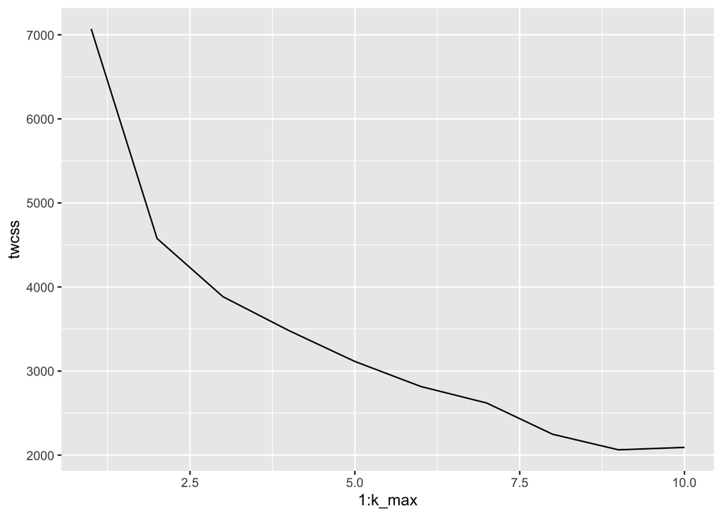

```r
set.seed(42)

# determine the maximum number of clusters
k_max <- 10

# calculate the total within sum of squares
twcss <- sapply(1:k_max, function(k){kmeans(boston_scaled, k)$tot.withinss})

# visualize the results
qplot(x = 1:k_max, y = twcss, geom = 'line')
```

The plot shows TWCSS on y-axis and how it changes with the number of clusters on x-axis. Here I chose to plot the TWCSS for 1-10 clusters (as it is very unlikely that the solution would be better for a larger number of clusters). The rule of thumb for choosing the appropriate number of clusters is to find a “knot” in the line, e.g. the point where there is a big drop in the TWCSS. In this case, it seems that 2 is a good number of clusters.

Let’s run the k-means algorithm with two clusters.

```r
# k-means clustering
km <- kmeans(boston_scaled, centers = 2)
km
```

```
## K-means clustering with 2 clusters of sizes 329, 177
##
## Cluster means:
##         crim         zn      indus         chas        nox         rm
## 1 -0.3894158  0.2621323 -0.6146857  0.002908943 -0.5823397  0.2446705
## 2  0.7238295 -0.4872402  1.1425514 -0.005407018  1.0824279 -0.4547830
##          age        dis        rad        tax    ptratio      black      lstat
## 1 -0.4331555  0.4540421 -0.5828749 -0.6291043 -0.2943707  0.3282754 -0.4530491
## 2  0.8051309 -0.8439539  1.0834228  1.1693521  0.5471636 -0.6101842  0.8421083
##         medv
## 1  0.3532917
## 2 -0.6566834
##
## Clustering vector:
##   1   2   3   4   5   6   7   8   9  10  11  12  13  14  15  16  17  18  19  20
```

[output cut: 60 more lines]

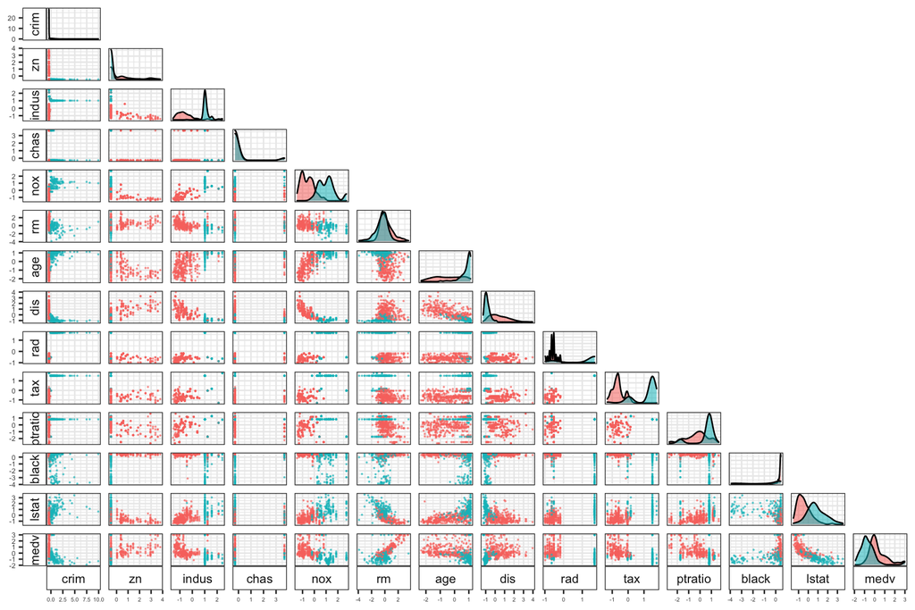

```r
# plot the Boston dataset with clusters

boston_scaled <- as.data.frame(boston_scaled)

plot2 <- ggpairs(boston_scaled,
             mapping = aes(col = as.factor(km$cluster), alpha = 0.1),
             lower = list(continuous = wrap("points", size = 0.1)),
             upper = "blank",
 switch = "both")+
  theme_bw() +
  theme(strip.background = element_rect(fill = "white"),
        axis.text.x = element_text(size=4),
        axis.text.y = element_text(size=5))

plot2
```